# c8w2_lecture_notes

R. Handsfield

September 14, 2016

# 1 The `caret` Package

The `caret` package has functions to simplify just about everything in data science/ machine learning.

## 1.1 Tutorials

- http://edii.uclm.es/~useR-2013/Tutorials/kuhn/user_caret_2up.pdf
- http://cran.r-project.org/web/packages/caret/vignettes/caret.pdf
- http://www.jstatsoft.org/v28/i05/paper
- https://www.youtube.com/watch?v=7Jbb2ItbTC4

## 1.2 Installation

Install with:

```r
if( !("caret" %in% installed.packages()) ) {
    install.packages("caret", dependencies = c("Depends", "Suggests"), repos = "http://cran.us.r-project.org");
}
library("caret");
```

## 1.3 Useful Caret Functions

**Preprocessing**

```r
preProcess(x, method = c("center", "scale"), thresh = 0.95,pcaComp = NULL,na.remove = TRUE,k = 5,knnSummary = mean,outcome = NULL,fudge = .2,numUnique = 3,verbose = FALSE,...)
```

**Segmenting Data**

```r
createDataPartition(y, times = 1, p = 0.5,list = TRUE, groups = min(5, length(y)))
```

```r
createResample(y, times = 10, list = TRUE)
```

```r
createFolds(y, k = 10, list = TRUE, returnTrain = FALSE)
```

```r
createMultiFolds(y, k = 10, times = 5)
```

```r
createTimeSlices(y, initialWindow, horizon = 1, fixedWindow = TRUE, skip = 0)
```

**Training and Testing**

```r
train(x, y, method = "rf", preProcess = NULL, ..., weights = NULL, metric = ifelse(is.factor(y), "Accuracy", "RMSE"), maximize = ifelse(metric %in% c("RMSE", "logLoss"), FALSE, TRUE), trControl = trainControl(), tuneGrid = NULL, tuneLength = 3)
```

```r
predict (object, ...)
```

**Comparing Models**

```r
confusionMatrix(data, reference, positive = NULL, dnn = c("Prediction", "Reference"), prevalence = NULL, mode = "sens_spec", ...)
```

All possible models are trained the same way – by passing a string to `caret::train(..., method='string', ...)`. The full list of method strings is below. For details see http://topepo.github.io/caret/using-your-own-model-in-train.html

```r
names(getModelInfo())
```

```
##   [1] "ada"                 "AdaBag"              "AdaBoost.M1"
##   [4] "adaboost"            "amdai"               "ANFIS"
##   [7] "avNNet"              "awnb"                "awtan"
##  [10] "bag"                 "bagEarth"            "bagEarthGCV"
##  [13] "bagFDA"              "bagFDAGCV"           "bam"
##  [16] "bartMachine"         "bayesglm"            "bdk"
##  [19] "binda"               "blackboost"          "blasso"
##  [22] "blassoAveraged"      "Boruta"              "bridge"
##  [25] "brnn"                "BstLm"               "bstSm"
##  [28] "bstTree"             "C5.0"                "C5.0Cost"
##  [31] "C5.0Rules"           "C5.0Tree"            "cforest"
##  [34] "chaid"               "CSimca"              "ctree"
##  [37] "ctree2"              "cubist"              "dda"
##  [40] "deepboost"           "DENFIS"              "dnn"
##  [43] "dwdLinear"           "dwdPoly"             "dwdRadial"
```

[output cut: 62 more lines]

### 1.3.1 Example: Creating Training Sets

Use `caret::createDataPartition( y=srcData, times=1, p=0.5, list=TRUE, groups=min(5, length(y)) )`:

```r
library(caret); library(kernlab); data(spam);

# creates a numeric vector that can subset from spam
inTrain<-createDataPartition(y=spam$type, p=0.75, list=FALSE)

training <- spam[inTrain, ]

# subsets rows NOT indexed by inTrain
testing <- spam[-inTrain, ]

dim(inTrain)
```

```
## [1] 3451    1
```

```r
# The training set
head( spam[inTrain, 1:8 ]);
```

```
##   make address  all num3d  our over remove internet
## 1 0.00    0.64 0.64     0 0.32 0.00   0.00     0.00
## 2 0.21    0.28 0.50     0 0.14 0.28   0.21     0.07
## 4 0.00    0.00 0.00     0 0.63 0.00   0.31     0.63
## 6 0.00    0.00 0.00     0 1.85 0.00   0.00     1.85
## 7 0.00    0.00 0.00     0 1.92 0.00   0.00     0.00
## 9 0.15    0.00 0.46     0 0.61 0.00   0.30     0.00
```

```r
# The test set
head(spam[-inTrain, 1:8]);
```

```
##    make address  all num3d  our over remove internet
## 3  0.06    0.00 0.71     0 1.23 0.19   0.19     0.12
## 5  0.00    0.00 0.00     0 0.63 0.00   0.31     0.63
## 8  0.00    0.00 0.00     0 1.88 0.00   0.00     1.88
## 15 0.00    0.00 1.42     0 0.71 0.35   0.00     0.35
## 16 0.00    0.42 0.42     0 1.27 0.00   0.42     0.00
## 21 0.00    0.00 0.00     0 0.00 0.00   0.00     0.00
```

Note the row numbers

### 1.3.2 Example: Fitting a Model

```r
set.seed(32343)

# trains a generalized linear model
modelFit <- train(type ~., data = training, method = 'glm')

# view summary of model
modelFit
```

```
## Generalized Linear Model
##
## 3451 samples
##   57 predictor
##    2 classes: 'nonspam', 'spam'
##
## No pre-processing
## Resampling: Bootstrapped (25 reps)
## Summary of sample sizes: 3451, 3451, 3451, 3451, 3451, 3451, ...
## Resampling results:
##
##   Accuracy   Kappa
##   0.9198818  0.8317119
##
##
```

```r
# view parameters (weights/theta) of final model
modelFit$finalModel
```

```
##
## Call:  NULL
##
## Coefficients:
##       (Intercept)               make            address
##        -1.617e+00         -5.494e-01         -1.528e-01
##               all              num3d                our
##         1.429e-01          3.733e+00          5.066e-01
##              over             remove           internet
##         9.540e-01          1.883e+00          1.234e+00
##             order               mail            receive
##         1.109e+00          1.423e-01          2.384e-01
##              will             people             report
##        -1.205e-01         -2.180e-01          7.444e-02
##         addresses               free           business
##         9.789e-01          9.337e-01          1.328e+00
##             email                you             credit
##         9.268e-02          1.011e-01          1.426e+00
##              your               font             num000
##         1.703e-01          1.655e-01          1.756e+00
##             money                 hp                hpl
##         3.088e-01         -2.713e+00         -6.414e-01
##            george             num650                lab
##        -2.036e+01          5.900e-01         -2.029e+00
##              labs             telnet             num857
##        -3.933e-01         -9.324e-02          1.108e+00
##              data             num415              num85
##        -1.068e+00          1.283e+00         -1.629e+00
##        technology            num1999              parts
##         1.210e+00          8.426e-02          1.833e+00
##                pm             direct                 cs
##        -7.681e-01         -3.524e-01         -5.684e+02
##           meeting           original            project
##        -3.583e+00         -1.929e+00         -1.578e+00
##                re                edu              table
##        -9.668e-01         -1.758e+00         -2.806e+00
##        conference      charSemicolon   charRoundbracket
##        -3.374e+00         -1.325e+00         -7.183e-01
## charSquarebracket    charExclamation         charDollar
##        -5.464e-01          3.031e-01          5.312e+00
##          charHash         capitalAve        capitalLong
##         2.525e+00          7.188e-02          7.347e-03
##      capitalTotal
##         1.131e-03
##
## Degrees of Freedom: 3450 Total (i.e. Null);  3393 Residual
## Null Deviance:       4628
## Residual Deviance: 1288  AIC: 1404
```

### 1.3.3 Example: Predicting with the Model

```r
predictions <- predict(object = modelFit, newdata = testing)

# produces a factor vector of class labels, 'spam' or 'nonspam'
predictions[1:16]
```

```
##  [1] spam    spam    spam    spam    spam    nonspam spam    nonspam
##  [9] spam    nonspam nonspam nonspam spam    spam    spam    spam
## Levels: nonspam spam
```

### 1.3.4 Example: Evaluating a Model

```r
confusionMatrix(data = predictions, reference = testing$type)
```

```
## Confusion Matrix and Statistics
##
##           Reference
## Prediction nonspam spam
##    nonspam     662   56
##    spam         35  397
##
##                Accuracy : 0.9209
##                  95% CI : (0.9037, 0.9358)
##     No Information Rate : 0.6061
##     P-Value [Acc > NIR] : < 2e-16
##
##                   Kappa : 0.8329
##  Mcnemar's Test P-Value : 0.03603
##
##             Sensitivity : 0.9498
##             Specificity : 0.8764
##          Pos Pred Value : 0.9220
##          Neg Pred Value : 0.9190
##              Prevalence : 0.6061
##          Detection Rate : 0.5757
##    Detection Prevalence : 0.6243
##       Balanced Accuracy : 0.9131
##
##        'Positive' Class : nonspam
##
```

## 1.4 Caret Prediction Algorithms

- Linear Discriminant Analysis
- Regression
- Naive Bays
- SVM
- Classification & Regression Trees
- Random Forest
- Boosting
- Etc

# 2 Data Slicing

### 2.0.1 Example: Random Subsampling

```r
library(caret); library(kernlab); data(spam);

# creates a numeric vector that can subset from spam
inTrain <- createDataPartition(y=spam$type, p=0.75, list=FALSE)

training <- spam[inTrain, ]
testing <- spam[-inTrain, ]
```

```r
dim(training); dim(testing)
```

```
## [1] 3451   58
```

```
## [1] 1150   58
```

### 2.0.2 Example: K-Fold Cross Val

- `k =` the number of folds
- `returnTrain=` specifies whether the folds are training or test folds
  - values = {`TRUE`, `FALSE`}
- `list=` determines the return structure data type
  - values = {`list`, `vector`, `matrix`}

```r
set.seed(32323)

# split data into 10 groups with random dropout in each
# returns a list of folds
# each fold is a numeric vector of row nums from spam$type
folds <- createFolds(y=spam$type, k=10, list=TRUE, returnTrain=TRUE) # vs returnTrain=FALSE for test set

# display num of examples in each fold, source had 4601 rows
sapply(folds, length)
```

```
## Fold01 Fold02 Fold03 Fold04 Fold05 Fold06 Fold07 Fold08 Fold09 Fold10
##   4141   4140   4141   4142   4140   4142   4141   4141   4140   4141
```

```r
# view row dropout in various folds
folds[[1]][1:20]; folds[[2]][1:20]
```

```
##  [1]  1  2  3  4  5  6  7  8  9 10 11 12 13 14 15 16 17 18 19 20
```

```
##  [1]  1  3  4  5  6  7  8  9 10 11 12 13 14 15 16 17 18 19 20 22
```

```r
# use folds to index data sets via
trn2 <- spam$type[folds[[2]]]]
val2 <- spam$type[-folds[[2]]]
```

or

```r
tst <- createFolds(y=spam$type, k=10, list=TRUE, returnTrain=FALSE) # vs returnTrain=TRUE for training set
```

Return the **training** set via something like `df[-tst, :]`

### 2.0.3 Example: Resampling

```r
set.seed(32323)

# fill each fold with random sample (with replacement) of rows
folds <- createResample(y = spam$type, times = 10, list = TRUE)

# view sizes of resampled folds, note the random collection of rows
sapply(folds, length)
```

```
## Resample01 Resample02 Resample03 Resample04 Resample05 Resample06
##       4601       4601       4601       4601       4601       4601
## Resample07 Resample08 Resample09 Resample10
##       4601       4601       4601       4601
```

```r
# note the repeated rows
folds[[1]][1:20]
```

```
##  [1]  1  2  3  3  3  5  5  7  8 12 12 12 13 13 13 14 14 15 16 16
```

### 2.0.4 Example: Time Series

- `initialWindow=` rows in the *training set*
- `horizon=` the next $n$ continuous rows (*test set*)

```r
set.seed(32323)

tme <- 1:1000

folds <- createTimeSlices(y = tme, initialWindow = 20, horizon = 10)

# what are the factors in each of our time slices?
names(folds)
```

```
## [1] "train" "test"
```

# 3 Training Options

Recall the generalized linear model trained on the `spam` dataset:

```r
library(caret); library(kernlab); data(spam);

inTrain <- createDataPartition(y=spam$type, p=0.75, list=FALSE)

training <- spam[inTrain, ]
testing <- spam[-inTrain, ]

modelFit <- train(type ~., data = training, method = 'glm')
```

The `caret::train()` has a number of options to control how training is done. (View any default method parameters with `base::args(functionName.default)`)

```r
library(caret)
args(train.default)
```

```
## function (x, y, method = "rf", preProcess = NULL, ..., weights = NULL,
##     metric = ifelse(is.factor(y), "Accuracy", "RMSE"), maximize = ifelse(metric %in%
##         c("RMSE", "logLoss"), FALSE, TRUE), trControl = trainControl(),
##     tuneGrid = NULL, tuneLength = 3)
## NULL
```

- `preProcess = NULL, ...` takes a string vector of preprocessing methods
  - { “BoxCox”, “YeoJohnson”, “expoTrans”, “center”, “scale”, “range”, “knnImpute”, “bagImpute”, “medianImpute”, “pca”, “ica” and “spatialSign”}
- `weights = NULL` takes a numeric vector of case weights, to manually up or down-weight observations
- `metric = ...` a string that specifies the cost function to minimize; by default is RMSE for numerics and fractional accuracy for factors
  - regression: {“RMSE”, “Rsquared”}
  - classification: {“Accuracy”, “Kappa”}
- `trControl = trainControl(...)` controls additional options
  - view via `?trainControl`

```r
args(trainControl)
```

```
## function (method = "boot", number = ifelse(grepl("cv", method),
##     10, 25), repeats = ifelse(grepl("cv", method), 1, number),
##     p = 0.75, search = "grid", initialWindow = NULL, horizon = 1,
##     fixedWindow = TRUE, verboseIter = FALSE, returnData = TRUE,
##     returnResamp = "final", savePredictions = FALSE, classProbs = FALSE,
##     summaryFunction = defaultSummary, selectionFunction = "best",
##     preProcOptions = list(thresh = 0.95, ICAcomp = 3, k = 5),
##     sampling = NULL, index = NULL, indexOut = NULL, indexFinal = NULL,
##     timingSamps = 0, predictionBounds = rep(FALSE, 2), seeds = NA,
##     adaptive = list(min = 5, alpha = 0.05, method = "gls", complete = TRUE),
##     trim = FALSE, allowParallel = TRUE)
## NULL
```

- `method = boot` the *resampling* method
  - {“boot”, “boot632”, “cv”, “repeatedcv”, “LOOCV”, “LGOCV”, “none”, “oob”, “adaptive_cv”, “adaptive_boot”, “adaptive_LGOCV”}
- `number =` the number of folds / resampling iterations (convergence limit??)
- `repeats =` the number repetitions for k-fold cross validation
- `initialWindow =` size of time series training set
- `horizon =` size of time series test set
- `savePredictions =` flag to return predictions from *each* iteration of model
  - {`"all"`, `"none"`, `"final"`} = {`TRUE`, `FALSE`, `"final"`}
- `allowParallel =` flag to enable parallel processing
- `seeds = NA` initializes the random number generator to a determined state
  - for parallel processing, seed each resample

# 4 Plotting Predictors

Plots are your friends. Git gud at them. For this section, we use example data from ISLR Package, the companion to the book Introduction to Statistical Learning with R.

Install with:

```r
if( !("ISLR" %in% installed.packages()) ) {
    install.packages("ISLR", repos = "http://cran.us.r-project.org");
}
```

### 4.0.1 Example: Wage Data

```r
library("ISLR"); library(ggplot2);

data(Wage)

summary(Wage)
```

```
##       year           age               sex                    maritl
##  Min.   :2003   Min.   :18.00   1. Male  :3000   1. Never Married: 648
##  1st Qu.:2004   1st Qu.:33.75   2. Female:   0   2. Married      :2074
##  Median :2006   Median :42.00                    3. Widowed      :  19
##  Mean   :2006   Mean   :42.41                    4. Divorced     : 204
##  3rd Qu.:2008   3rd Qu.:51.00                    5. Separated    :  55
##  Max.   :2009   Max.   :80.00
##
##        race                   education                     region
##  1. White:2480   1. < HS Grad      :268   2. Middle Atlantic   :3000
##  2. Black: 293   2. HS Grad        :971   1. New England       :   0
##  3. Asian: 190   3. Some College   :650   3. East North Central:   0
##  4. Other:  37   4. College Grad   :685   4. West North Central:   0
##                  5. Advanced Degree:426   5. South Atlantic    :   0
##                                           6. East South Central:   0
##                                           (Other)              :   0
##            jobclass               health      health_ins      logwage
##  1. Industrial :1544   1. <=Good     : 858   1. Yes:2083   Min.   :3.000
##  2. Information:1456   2. >=Very Good:2142   2. No : 917   1st Qu.:4.447
##                                                            Median :4.653
##                                                            Mean   :4.654
##                                                            3rd Qu.:4.857
##                                                            Max.   :5.763
##
##       wage
##  Min.   : 20.09
##  1st Qu.: 85.38
##  Median :104.92
##  Mean   :111.70
##  3rd Qu.:128.68
##  Max.   :318.34
##
```

Set aside a test set (and validation set) **before** beginning exploratory analysis.

```r
inTrain <- createDataPartition(y = Wage$wage, p = 0.7, list = FALSE)

training <- Wage[inTrain,]
testing <- Wage[-inTrain,]

dim(training); dim(testing)
```

```
## [1] 2102   12
```

```
## [1] 898  12
```

### 4.0.2 Example: Lattice Plot a Subset of Wage Features

Using `caret::featurePlot()`

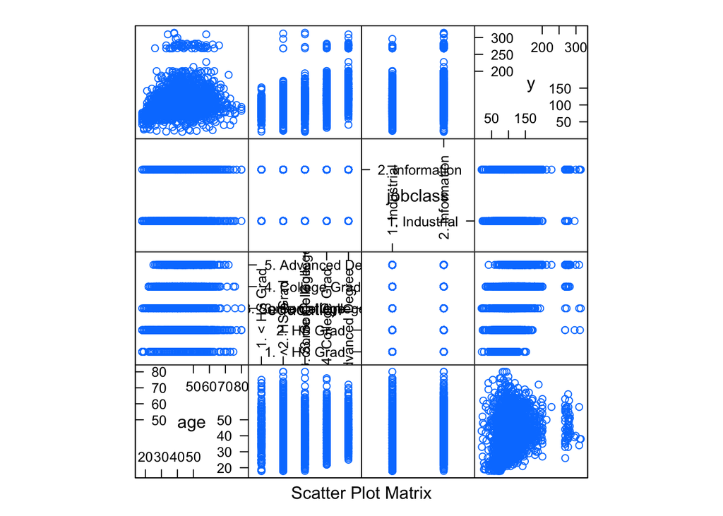

```r
# choose 3 features
mySet <- training[, c('age', 'education', 'jobclass')]

# plot wage as a function of features (4x4 = 16)
featurePlot(x=mySet, y=training$wage, plot='pairs')
```

### 4.0.3 Example: Scatter Plot Wage vs Age

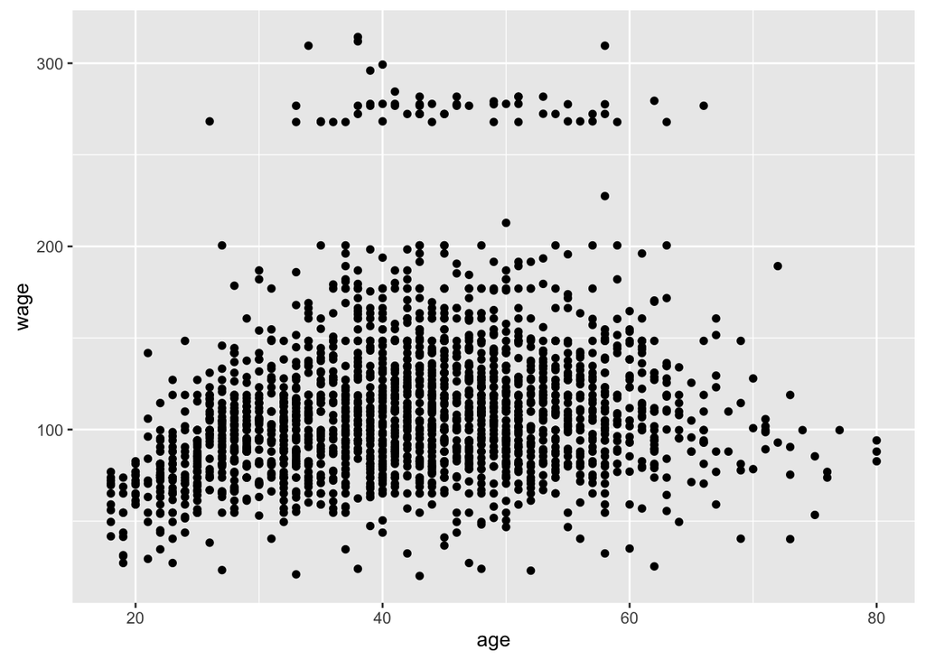

```r
ggplot(data=training) + aes(x=age, y=wage) + geom_point()
```

Note the natural vertical segregation. How to investigate this further?

Answer: color the scatter by an additional feature:

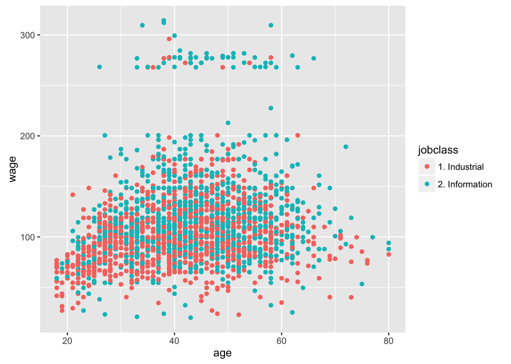

```r
ggplot(data=training) + aes(x=age, y=wage, color=jobclass) + geom_point()
```

Very few industrial jobs are in the upper group.

### 4.0.4 Example: Plot with Feature Regressions

It is easy to do simple regressions inside a plot, for easy viewing. Oddly, it’s actually very difficult to do your own regression, then add that to a plot. Proceed accordingly!

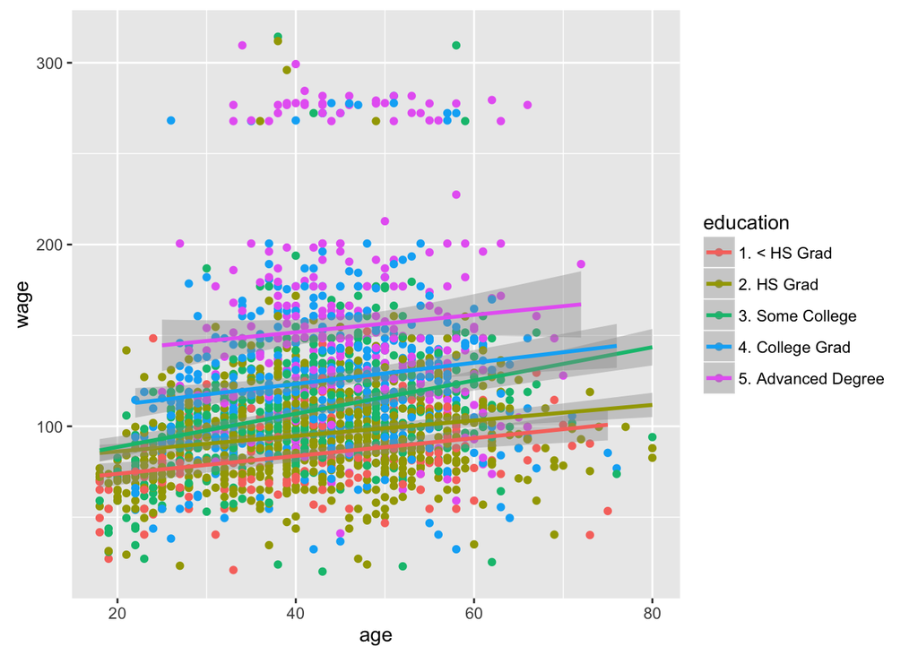

```r
g <- ggplot(data=training) + aes(x=age, y=wage, color=education) + geom_point()

# add linear regression: wage = f(age)
g <- g + geom_smooth(method = "lm", formula = y~x)
print(g)
```

Regression lines have been added to plot

### 4.0.5 Example: Plot by Quantiles

The method here is to pseudo-manually cut the data with `Hmisc::cut2()`, then plot the resulting quantiles.

```r
if( !("Hmisc" %in% installed.packages()) ) {
    install.packages("Hmisc", repos = "http://cran.us.r-project.org");
}
```

```r
library(Hmisc)
cutWage <- cut2(training$wage, g=3)
table(cutWage)
```

```
## cutWage
## [ 20.1, 93.1) [ 93.1,118.9) [118.9,314.3]
##           713           708           681
```

```r
t1 <- table(cutWage, training$jobclass)
t1
```

```
##
## cutWage         1. Industrial 2. Information
##   [ 20.1, 93.1)           449            264
##   [ 93.1,118.9)           361            347
##   [118.9,314.3]           275            406
```

```r
# a proportional table
prop.table(x = t1, margin = 1)  # margin=dimension
```

```
##
## cutWage         1. Industrial 2. Information
##   [ 20.1, 93.1)     0.6297335      0.3702665
##   [ 93.1,118.9)     0.5098870      0.4901130
##   [118.9,314.3]     0.4038179      0.5961821
```

Plot this table to look for trends

```r
library(gridExtra)
```

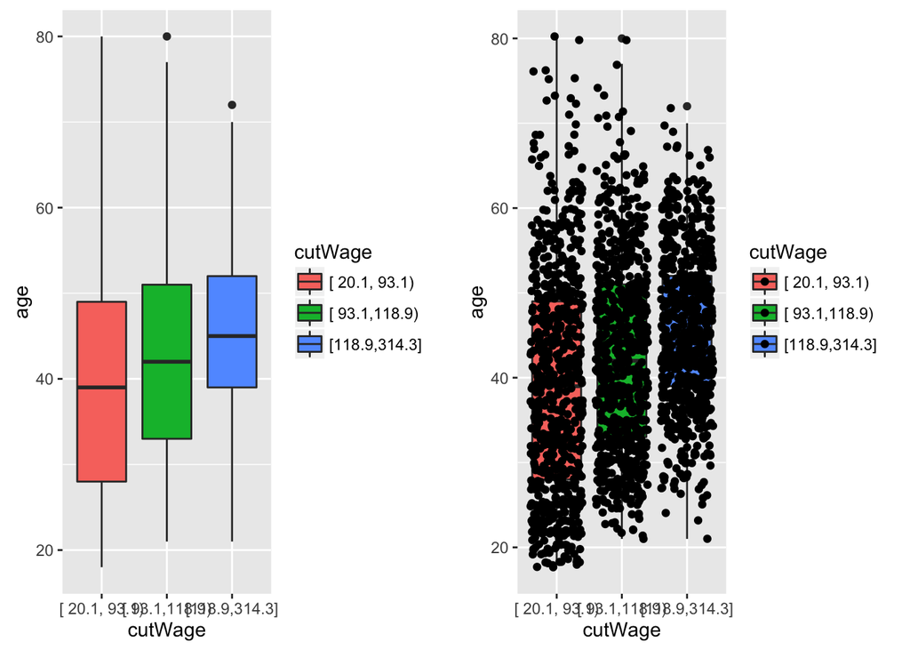

```r
g1 <- ggplot(data=training) + aes(x=cutWage, y=age, fill=cutWage) + geom_boxplot()

# view points on top of boxplot
g2 <- ggplot(data=training) + aes(x=cutWage, y=age, fill=cutWage) + geom_boxplot() + geom_jitter()
grid.arrange(g1,g2, ncol=2)
```

### 4.0.6 Example: A Density Plot of Wage by Quantile

For continuous predictors

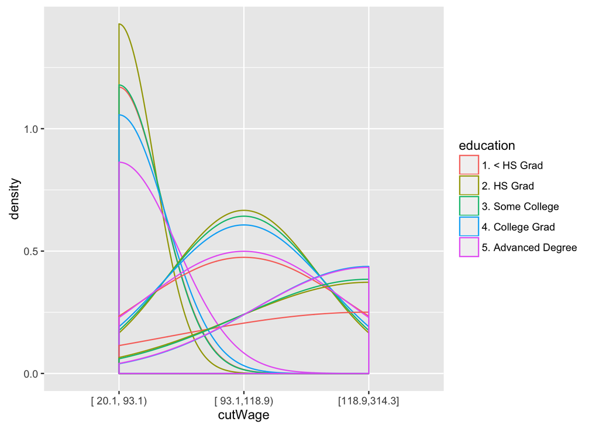

```r
ggplot(data=training) + aes(x=cutWage, color=education) + geom_density()
```

All of the above are ways to examine properties of your data set, but **don’t** use your *test* set for exploration.

You’re always looking for

- trends
- skewed variables
- imbalance in outcomes/predictors
- outcomes not explained by predictors

# 5 Basic Preprocessing

After plotting the variables up front, it’s time to prep the data set for training.

Consider the `kernlab::spam` data set one more time:

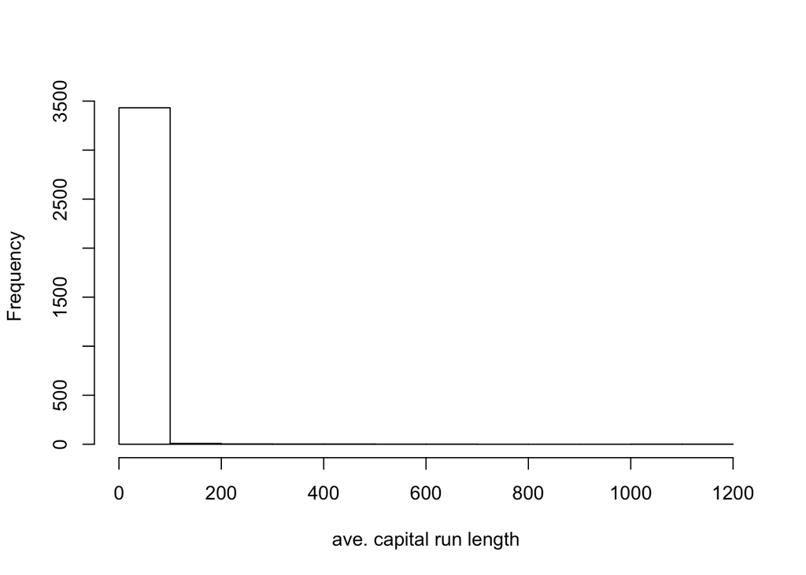

```r
library(caret); library(kernlab); data(spam);

# creates a numeric vector that can subset from spam
inTrain<-createDataPartition(y=spam$type, p=0.75, list=FALSE)

training <- spam[inTrain, ]
testing <- spam[-inTrain, ]

hist(training$capitalAve, main="", xlab="ave. capital run length")
```

This is the distribution of capital letter sequence length between spam/nonspam. This variable is highly skewed, and will bone most learning algorithms. We can redress this by shifting/stretching/squashing the input data and writing the result to an *R::caret Preprocess Object*. That object becomes the training inputs to a hypothesis function, and we pass it to the `caret::train(type= ,data=preObj, method="string")` and `caret::predict(object=preObj, newdata=groundTruth`) functions.

1. Preprocess an input set with `preObj <- preProcess(object = inputSet , method = "" )`
2. Pass the Preprocess Object to another caret function: `predict(object = preObj, newdata = groundTruth)`

## 5.1 The Statistical Z-Transform

One way to fix model-boning is by doing a statistical z-transform on the data:

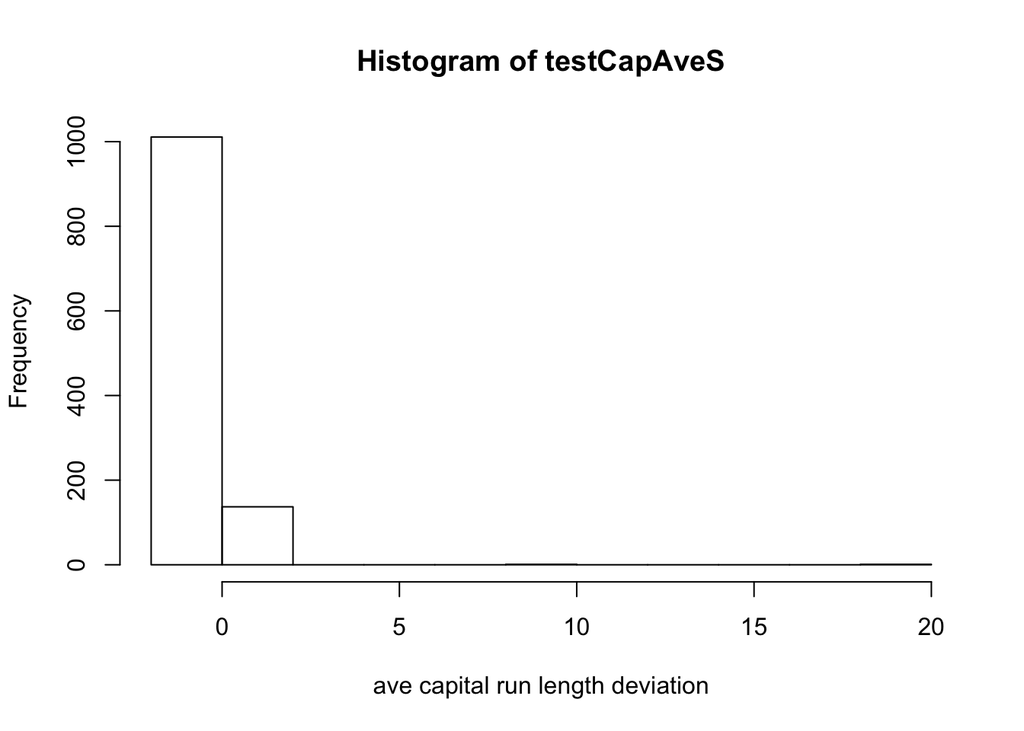

```r
testCapAve <- testing$capitalAve

# z-transform based on training set distribution
testCapAveS <- (testCapAve - mean(training$capitalAve)) / sd(training$capitalAve)

hist(testCapAveS, xlab="ave capital run length deviation")
```

Another way to do this is with the `caret::preProcess()` function:

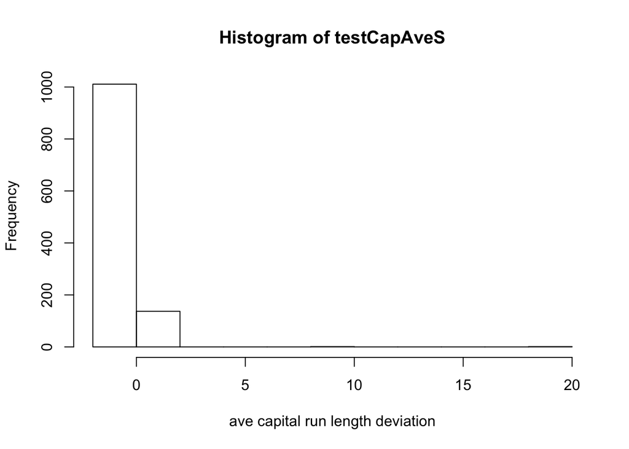

```r
# col 58 is the ground-truth outcome
preObj <- preProcess( training[,-58], method=c("center", "scale") )

# pass the Preprocess object into the predict() method
trainCapAveS <- predict(preObj, training[,-58])$capitalAve
hist(testCapAveS, xlab="ave capital run length deviation")
```

To z-transform the corresponding test set, you would create a Preprocess Object from the *training set*, then pass that object to `predict()`, along with the *testing set*:

```r
preObj <- preProcess( training[,-58], method=c("center", "scale") )

# must pass subset of same dims to preProcess() and predict(): ex train[-58] vs test[-58]
trainCapAveS <- predict(preObj, training[,-58])$capitalAve
testCapAveS <- predict(preObj, testing[,-58])$capitalAve
```

You could also pass the `preProcess()` function as an argument to `train()`:

```r
set.seed(32343)

modelFit <- train(type ~., data=training, method="glm", preProcess=c("center", "scale"))
modelFit
```

```
## Generalized Linear Model
##
## 3451 samples
##   57 predictor
##    2 classes: 'nonspam', 'spam'
##
## Pre-processing: centered (57), scaled (57)
## Resampling: Bootstrapped (25 reps)
## Summary of sample sizes: 3451, 3451, 3451, 3451, 3451, 3451, ...
## Resampling results:
##
##   Accuracy   Kappa
##   0.9116024  0.8163398
##
##
```

## 5.2 Box-Cox Transform

Other preprocessing transforms are avaialable. The *Box-Cox* is a power transform takes any continuous variable and forces it to fit a normal distribution by introducing a new parameter $\lambda$

$$\mbox{for } y \geq 0: ~~
y(\lambda) = \left\{\begin{matrix}
\frac{ y^{\lambda}-1 }{\lambda}, & \mbox{if } \lambda \neq 0\\
log(y), & \mbox{if } \lambda = 0
\end{matrix}\right.$$

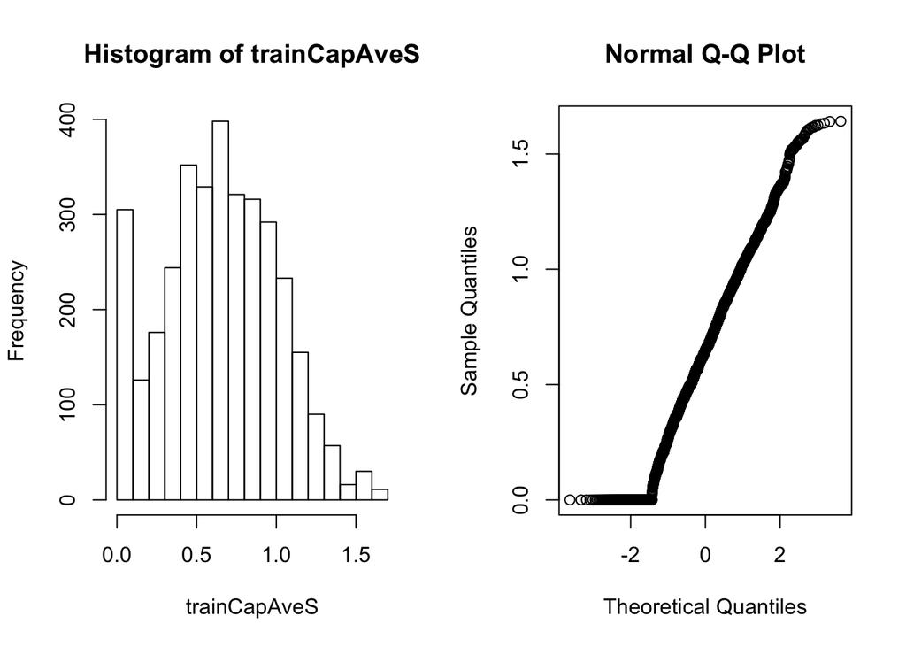

```r
preObj <- preProcess(training[,-58], method=c("BoxCox"))

trainCapAveS <- predict(object = preObj, newdata = training[,-58])$capitalAve

par(mfrow=c(1,2))
hist(trainCapAveS)
qqnorm(trainCapAveS)
```

## 5.3 Imputing Data

*Imputing* is the process of assigning values to `NA`s in the data set. Imputing may use any number of interpolation methods. A common method is *k nearest neighbors*, which averages the values surrounding each `NA`.

This is super easy, just add `"knnImpute"` to `preProcess(..., method="...")`:

```r
set.seed(13343)

# introduce NAs
training$capAve <- training$capitalAve  # copy a column
selectNA <- rbinom(dim(training)[1], size=1, prob=.5) == 1  # make a boolean vector
training$capAve[selectNA] <- NA  # overwrite some values with NA

# Impute and standardize
preObj <- preProcess(training[,-58], method=c("knnImpute"))
capAve <- predict(preObj, training[,-58])$capAve

# Standardize the values
capAveTruth <- training$capitalAve
capAveTruth <- (capAveTruth - mean(capAveTruth)) / sd(capAveTruth)

quantile(capAve - capAveTruth)
```

```
##           0%          25%          50%          75%         100%
## -6.552565113 -0.004786531  0.007954623  0.014351073  0.716373528
```

```r
quantile((capAve - capAveTruth)[selectNA])
```

```
##          0%         25%         50%         75%        100%
## -6.26513752 -0.01168132  0.01008928  0.02320144  0.71637353
```

```r
quantile((capAve - capAveTruth)[!selectNA])
```

```
##           0%          25%          50%          75%         100%
## -6.552565113 -0.001711543  0.007131843  0.011186118  0.014763419
```

Be mindful that if you preprocess training data, you **cannot** preprocess test data when predicting; you must reuse the preprocessed training data. The reason is that **any** transformation creates new features, and creating new features on a test set will skew the predictions in unpredictable ways.

# 6 Creating Covariates

A *covariate* is yet another name for a model feature. In the real world, not all data variables make it into the model. Covariates (or features, or predictors) have the implicit meaning that they may have been subset from a larger group, and are intended for model inclusion.

Covariates are created in 2 levels, which sort of correspond to in-model and out-model. The goal is to include the most data in the fewest number of features (e.g. maximize data density).

- Level 1: Raw data to covariats
  - email ascii text into numeric descriptive variables num caps, frac ngrams, etc.
  - image into pixel subsets representing edges, corners, blobs, etc.
  - rendering of a website into a DOM object with element parameters - color, size, etc
- Level 2: Transformivariables into tidy covariates
  - Ex: If $A \times B$ is an important feature, create new variable $~~ \mbox{aTimesB} = A \times B$
  - many `caret` functions to simplify this

## 6.1 Discussion

Creating covariates is delicate balancing act between information density (summarization) and information loss. It requires substantial application knowledge and domain expertise.

- Level 1
  - When in doubt, err on the side of more features
  - Can be automated, but don’t do it; it rarely works
- Level 2
  - only done on training sets
  - often necessary for regressions and SVMs
  - rarely needed for classification trees
  - achived through exploratory analysis
  - new covariates should be added to data frames
  - use practical variable names

## 6.2 Dummy Variables

*Dummy Variables* are a stupid way to describe the process of converting factor levels into feature variables. If there is a factor variable with 2 levels, create a new feature for each level. Each of those features will have a boolean value for each example. This process expands the data space, widens the data set, and is also known as *one-hot encoding*.

```r
library(ISLR); library(caret); data(Wage);

inTrain <- createDataPartition(y=Wage$wage, p=0.7, list=FALSE)
training <- Wage[inTrain,]; testing <- Wage[-inTrain,]
```

Explore the data

```r
table(training$jobclass)
```

[output not shown]

Create 2 new variables for these classes with `caret::dummyVars(formula = , data = , ...)`

```r
dummies <- dummyVars(formula = wage~jobclass, data = training)

str(dummies)
```

```
## List of 9
##  $ call      : language dummyVars.default(formula = wage ~ jobclass, data = training)
##  $ form      :Class 'formula'  language wage ~ jobclass
##   .. ..- attr(*, ".Environment")=<environment: R_GlobalEnv>
##  $ vars      : chr [1:2] "wage" "jobclass"
##  $ facVars   : chr "jobclass"
##  $ lvls      :List of 1
##   ..$ jobclass: chr [1:2] "1. Industrial" "2. Information"
##  $ sep       : chr "."
##  $ terms     :Classes 'terms', 'formula'  language wage ~ jobclass
##   .. ..- attr(*, "variables")= language list(wage, jobclass)
##   .. ..- attr(*, "factors")= int [1:2, 1] 0 1
##   .. .. ..- attr(*, "dimnames")=List of 2
##   .. .. .. ..$ : chr [1:2] "wage" "jobclass"
##   .. .. .. ..$ : chr "jobclass"
##   .. ..- attr(*, "term.labels")= chr "jobclass"
##   .. ..- attr(*, "order")= int 1
##   .. ..- attr(*, "intercept")= int 1
##   .. ..- attr(*, "response")= int 1
##   .. ..- attr(*, ".Environment")=<environment: R_GlobalEnv>
##   .. ..- attr(*, "predvars")= language list(wage, jobclass)
##   .. ..- attr(*, "dataClasses")= Named chr [1:2] "numeric" "factor"
##   .. .. ..- attr(*, "names")= chr [1:2] "wage" "jobclass"
##  $ levelsOnly: logi FALSE
##  $ fullRank  : logi FALSE
##  - attr(*, "class")= chr "dummyVars"
```

```r
head(predict(object = dummies, newdata = training))
```

```
##        jobclass.1. Industrial jobclass.2. Information
## 86582                       0                       1
## 161300                      1                       0
## 155159                      0                       1
## 11443                       0                       1
## 376662                      0                       1
## 450601                      1                       0
```

The training set now has a boolean flag for each person and job class.

## 6.3 Maximizing Feature Variability

Some features, both qualitative, quantitative, and boolean, have very little variability, and won’t add much information to a model. Finding numeric features of this kind is easy with `caret::nearZeroVar(x= , freqCut = 95/5, uniqueCut = 10)` or `caret::nzv()`

For `nearZeroVar()`: if `saveMetrics = FALSE`, returns a vector of integers corresponding to the column positions of the problematic predictors. If `saveMetrics = TRUE`, a data frame with columns:

```r
nsv <- nearZeroVar(x = training, saveMetrics = TRUE)
nsv
```

```
##            freqRatio percentUnique zeroVar   nzv
## year        1.037356    0.33301618   FALSE FALSE
## age         1.027027    2.85442436   FALSE FALSE
## sex         0.000000    0.04757374    TRUE  TRUE
## maritl      3.272931    0.23786870   FALSE FALSE
## race        8.938776    0.19029496   FALSE FALSE
## education   1.389002    0.23786870   FALSE FALSE
## region      0.000000    0.04757374    TRUE  TRUE
## jobclass    1.000000    0.09514748   FALSE FALSE
## health      2.468647    0.09514748   FALSE FALSE
## health_ins  2.352472    0.09514748   FALSE FALSE
## logwage     1.061728   19.17221694   FALSE FALSE
## wage        1.061728   19.17221694   FALSE FALSE
```

- freqRatio: the ratio of frequencies for the most common value over the second most common value
- percentUnique: the percentage of unique data points out of the total number of data points
- zeroVar: a vector of logicals for whether the predictor has **only one distinct value**
- nzv: a vector of logicals for whether the predictor **is a near zero variance predictor**

## 6.4 Creating Polynomial Covariates

Recall that creating polynomial features is a simple way to improve model fit. Again, this is super easy with the splines package `splines::bs` function.

From the `training$age` variable, we want to create $\{age, age^2, age^3 \}$:

```r
library(splines)

# uses B-splines with 3 dof
bsBasis <- bs(training$age, df=3)
head(bsBasis, 3L)
```

```
##              1          2           3
## [1,] 0.2368501 0.02537679 0.000906314
## [2,] 0.4163380 0.32117502 0.082587862
## [3,] 0.4308138 0.29109043 0.065560908
```

### 6.4.2 Example: Fitting Splines

For computational efficiency, in practice the modeling code should be separated from the plotting code.

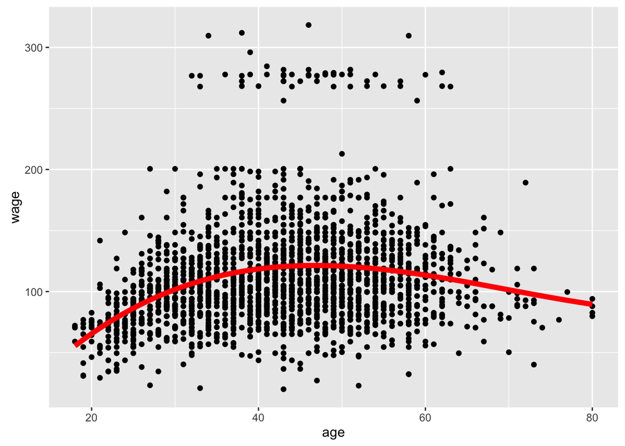

```r
lm1 <- lm(wage~bsBasis, data=training)

# the spline will be the y-arg of a geom_line()
splineLine <- predict(object = lm1, newdata = training)

g <- ggplot(data=training) + aes(x=age, y=wage) + geom_point()

g <- g + geom_line(aes(x=age, y=splineLine), color='red', lwd=2)
print(g)
```

- `caret:gam()` also works, but is more complicated

# 7 Preprocessing with Principal Components (PCA)

Principal Components Analysis will segment out variables that are highly correlated.

Once again, the `kernlab::spam` dataset:

```r
library(caret); library(kernlab); data(spam);

# creates a numeric vector that can subset from spam
inTrain<-createDataPartition(y=spam$type, p=0.75, list=FALSE)

training <- spam[inTrain, ]
testing <- spam[-inTrain, ]

M <- abs(cor(x = training[,-58]))
diag(M) <- 0  # remove autocorrelations
which(M > 0.9, arr.ind=TRUE) # which vars are more than 90% correlated?
```

```
##        row col
## num415  34  32
## num857  32  34
```

Two features are highly correlated: num415, num857. Double check to be sure:

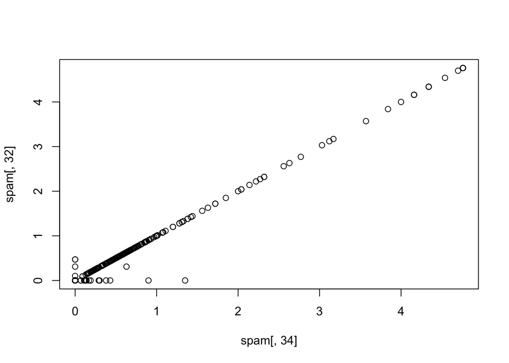

```r
# index by col num if you don't have the names
plot(spam[,34], spam[,32])
```

A straight line with $slope \approx 1$; this is almost perfect correlation. A weighted combination of these features might capture most of the variance while removing all the correlation. Extending this idea, we want to find the smallest matrix $M$ (subset) that captures the most variability (best explains) the original set. This matrix can be found via SVD/PCA

## 7.1 The Singular Value Decomposition (SVD)

Take an original matrix $X$ and decompose it into a product of 3 matrices such that

$$X = UDV^T$$

- columns of $U$ are orthogonal (left singular vectors)
- $D$ is a diagonal matrix (singular values)
- columns of $V$ are orthogonal (right singular vectors)
  - (in most real data sets, if $X$ is factorable, then $U = V$)

## 7.2 The Principal Components

The Principal Components of $X$ capture the most variability of $X$ in descending cardinality order. Conveniently, **if** the input variables have been scaled and mean-shifted (z-transformed), the principal components are equal to the columns of $V$ (often also $U$).

Principal Components are very easy to find with `stats::prcomp()`

### 7.2.1 Example: PCA of Correlated Variables

From the previous example, columns 32 and 32 of `spam` are correlated:

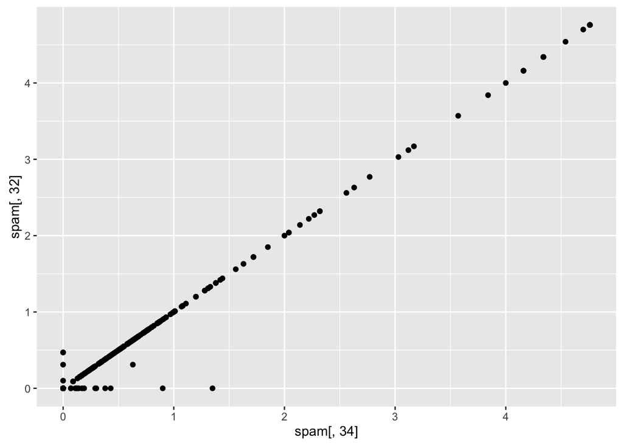

```r
ggplot() + aes(spam[,34], spam[,32]) + geom_point()
```

If we find and plot the principal components of these variables:

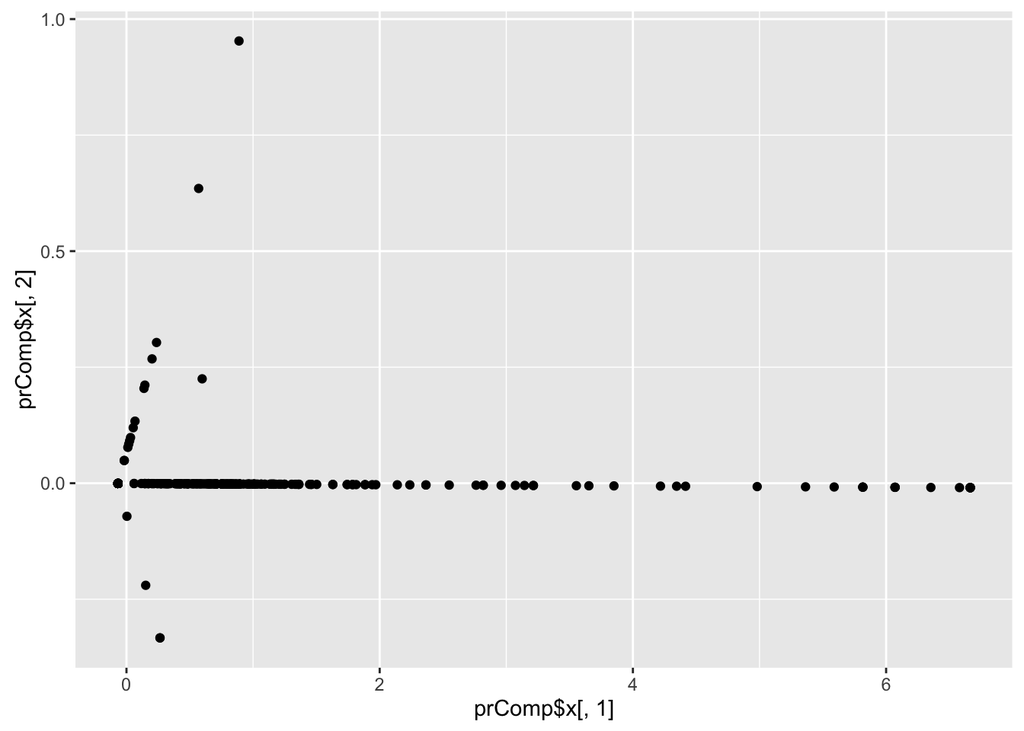

```r
prComp <- prcomp(x = spam[,c(34,32)] )

# plot the first 2 principal components
ggplot() + aes(prComp$x[,1], prComp$x[,2]) + geom_point()
```

Mostly flat line, there is almost no correlation between the first 2 principle components of `num415` and `num857`.

What does the rotation matrix look like?

```r
round( prComp$rotation, digits=4)
```

```
##           PC1     PC2
## num415 0.7081  0.7061
## num857 0.7061 -0.7081
```

### 7.2.2 Exampple: PCA with R::stats

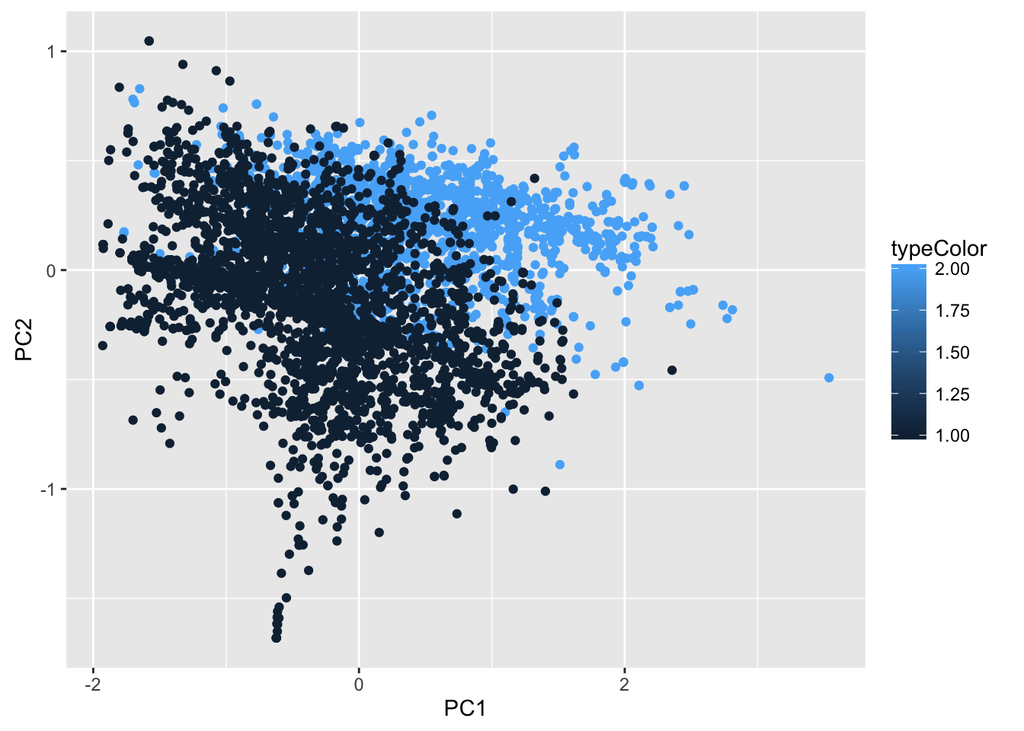

```r
typeColor <- ((spam$type=="spam")*1 + 1)
prComp <- prcomp(x = log10(spam[ , -58]+1) )  # Gaussify to correct data skew (log10(...))

ggplot() + aes(prComp$x[,1], prComp$x[,2], color = typeColor) + geom_point() +
        xlab("PC1") + ylab("PC2")
```

The principal components are pretty distinct.

### 7.2.3 Example: PCA with R::caret

During preprocessing (the `preProcess()` method), use `method="pca"`):

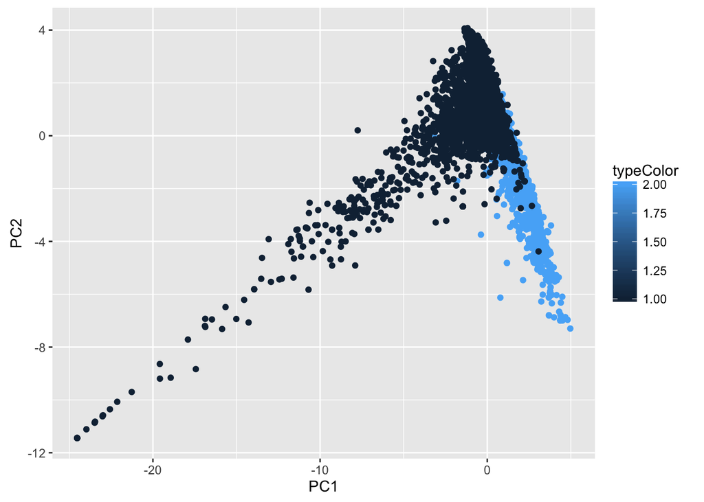

```r
# log10(...) Gaussifies the input for better PCA results
preProc <- preProcess(log10(spam[,-58]+1), method="pca", pcaComp=2)

# the principal components matrix is actually created with predict()
spamPC <- predict(object = preProc, newdata = log10(spam[,-58]+1))

ggplot() + aes(spamPC[,1], spamPC[,2], color=typeColor) + geom_point() +
        xlab("PC1") + ylab("PC2")
```

Principal Components still pretty distinct.

### 7.2.4 Example: Fitting to Principal Components

From the previous example, `spamPC` is the training set, the first 2 principal components of `kernlab::spam`.

```r
# scales & shifts for pca
preProc <- preProcess(log10(training[,-58]+1), method="pca", pcaComp=2)

# predict() actually does the PCA, returning the PCM
trainPC <- predict(object = preProc, newdata = log10(training[,-58]+1))

trainPC$type <- training$type
modelFit <- train(type ~., data=trainPC, method="glm")
# modelFit <- train(type ~., data = training, method = 'glm')
modelFit$results
```

```
##   parameter  Accuracy     Kappa  AccuracySD    KappaSD
## 1      none 0.9056476 0.8011514 0.005884655 0.01226668
```

```r
# make some predictions with this model
testPC <- predict(preProc, log10(testing[,-58]+1))
confusionMatrix(testing$type, predict(object=modelFit, newdata=testPC))
```

```
## Confusion Matrix and Statistics
##
##           Reference
## Prediction nonspam spam
##    nonspam     645   52
##    spam         73  380
##
##                Accuracy : 0.8913
##                  95% CI : (0.8719, 0.9087)
##     No Information Rate : 0.6243
##     P-Value [Acc > NIR] : < 2e-16
##
##                   Kappa : 0.7705
##  Mcnemar's Test P-Value : 0.07364
##
##             Sensitivity : 0.8983
##             Specificity : 0.8796
##          Pos Pred Value : 0.9254
##          Neg Pred Value : 0.8389
##              Prevalence : 0.6243
##          Detection Rate : 0.5609
##    Detection Prevalence : 0.6061
##       Balanced Accuracy : 0.8890
##
##        'Positive' Class : nonspam
##
```

A simpler form for doing the same thing is

```r
modelFit <- train(type ~ ., method="glm", preProcess="pca", data=training)
confusionMatrix(testing$type, predict(modelFit, testing))
```

```
## Confusion Matrix and Statistics
##
##           Reference
## Prediction nonspam spam
##    nonspam     658   39
##    spam         50  403
##
##                Accuracy : 0.9226
##                  95% CI : (0.9056, 0.9374)
##     No Information Rate : 0.6157
##     P-Value [Acc > NIR] : <2e-16
##
##                   Kappa : 0.8372
##  Mcnemar's Test P-Value : 0.2891
##
##             Sensitivity : 0.9294
##             Specificity : 0.9118
##          Pos Pred Value : 0.9440
##          Neg Pred Value : 0.8896
##              Prevalence : 0.6157
##          Detection Rate : 0.5722
##    Detection Prevalence : 0.6061
##       Balanced Accuracy : 0.9206
##
##        'Positive' Class : nonspam
##
```

# 8 Predicting with Univariate Regression

# 9 Predicting with Multivariate Regression